# Python Statistical Analysis in Practice — 01: Simulation Basics

*Author: Jason JJ Li · Peking University Institute of Population Research*

This first tutorial introduces the core technique used throughout this series: **learning statistics by generating your own data**. When you simulate data with known parameters, you always know the "true answer" — so you can directly verify how well any statistical method works.

**The four-step loop used in every post:**

1. **Simulate** — generate data with known parameters
2. **Estimate** — apply a statistical method
3. **Verify** — compare estimates against the known truth
4. **Explore** — vary conditions and observe how results change

## Part 1: Environment Setup

```python
import pandas as pd
import numpy as np
from scipy import stats
import matplotlib.pyplot as plt
import matplotlib.gridspec as gridspec
import seaborn as sns
import warnings

warnings.filterwarnings('ignore')
plt.style.use('seaborn-v0_8-whitegrid')
pd.set_option('display.precision', 3)
pd.set_option('display.float_format', '{:.3f}'.format)

COLORS = {
    'primary':   '#2E86AB',
    'secondary': '#A23B72',
    'accent':    '#F18F01',
    'success':   '#27AE60',
    'danger':    '#E74C3C',
    'neutral':   '#95A5A6',
}

# Global random number generator — set once, reuse everywhere
RNG = np.random.default_rng(42)

print('Libraries loaded successfully.')
print(f'NumPy  : {np.__version__}')
print(f'Pandas : {pd.__version__}')
```

```
Libraries loaded successfully.
NumPy  : 2.4.2
Pandas : 2.3.3
```

## Part 2: Why Simulated Data?

Traditional statistics courses rely on real datasets — but you never know the *true* parameter values, so you can never verify whether your estimates are accurate.

Simulated data solves this:

| Problem with real data | Simulation solution |
| --- | --- |
| Hard to obtain | One line of code generates any dataset |
| True answer unknown | We set the true parameters ourselves |
| Can't test edge cases | Precisely control sample size, distributions, missing rates |
| Hard to reproduce | Random seed guarantees identical results |
| Effect size is abstract | Set the true effect, then observe estimated effect |

### 2.1 The Random Seed: Reproducibility Starts Here

```python
# Without a seed: results change every run
print('=== Without seed ===')
for i in range(3):
    x = np.random.normal(0, 1, 5).round(3)
    print(f'  Run {i+1}: {x}')

print()

# With a fixed seed: always identical
print('=== With seed=42 ===')
for i in range(3):
    rng = np.random.default_rng(42)
    x = rng.normal(0, 1, 5).round(3)
    print(f'  Run {i+1}: {x}')

print()
print('✓ With a seed, every run produces the exact same numbers.')
```

```
=== Without seed ===
  Run 1: [-0.367  0.951  1.285  0.95  -0.086]
  Run 2: [-1.447  1.634  0.454 -0.057 -1.215]
  Run 3: [ 0.441  1.116 -0.653 -0.195 -1.321]

=== With seed=42 ===
  Run 1: [ 0.305 -1.04   0.75   0.941 -1.951]
  Run 2: [ 0.305 -1.04   0.75   0.941 -1.951]
  Run 3: [ 0.305 -1.04   0.75   0.941 -1.951]

✓ With a seed, every run produces the exact same numbers.
```

## Part 3: Generating Common Distributions

### 3.1 The Five Distributions Used in This Series

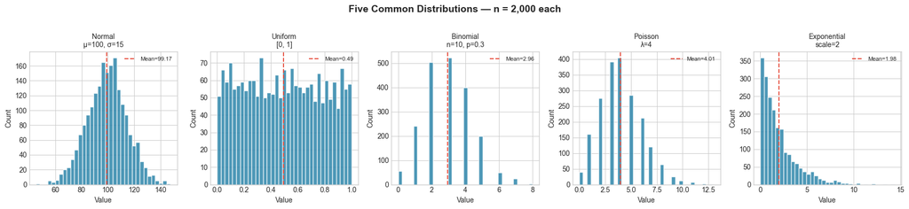

```
Summary statistics:
                       Mean    Std    Min     Max
Normal μ=100, σ=15   99.173 15.027 45.274 147.683
Uniform [0, 1]        0.494  0.289  0.001   1.000
Binomial n=10, p=0.3  2.957  1.433  0.000   8.000
Poisson λ=4           4.009  2.053  0.000  13.000
Exponential scale=2   1.978  1.920  0.000  14.393
```

```python
RNG = np.random.default_rng(42)
N = 2000

distributions = {
    'Normal\nμ=100, σ=15':       RNG.normal(loc=100, scale=15, size=N),
    'Uniform\n[0, 1]':            RNG.uniform(low=0, high=1, size=N),
    'Binomial\nn=10, p=0.3':      RNG.binomial(n=10, p=0.3, size=N).astype(float),
    'Poisson\nλ=4':               RNG.poisson(lam=4, size=N).astype(float),
    'Exponential\nscale=2':       RNG.exponential(scale=2, size=N),
}

fig, axes = plt.subplots(1, 5, figsize=(18, 4))
fig.suptitle('Five Common Distributions — n = 2,000 each', fontsize=14, fontweight='bold', y=1.02)

for ax, (name, data) in zip(axes, distributions.items()):
    ax.hist(data, bins=35, color=COLORS['primary'], edgecolor='white', alpha=0.85)
    ax.set_title(name, fontsize=10)
    ax.set_xlabel('Value')
    ax.set_ylabel('Count')
    ax.axvline(np.mean(data), color=COLORS['danger'], linestyle='--', linewidth=1.5, label=f'Mean={np.mean(data):.2f}')
    ax.legend(fontsize=8)

plt.tight_layout()
plt.show()

print('\nSummary statistics:')
summary = pd.DataFrame({
    name.replace('\n', ' '): {'Mean': d.mean(), 'Std': d.std(), 'Min': d.min(), 'Max': d.max()}
    for name, d in distributions.items()
}).T
print(summary.round(3).to_string())
```

## Part 4: Three-Step Data Validation

Before applying any statistical method, always validate that your simulated data looks as expected.

### Step 1 — Summary statistics

### Step 2 — Histogram

### Step 3 — Q-Q plot

```
=== Step 1: Summary Statistics ===
  n          : 200
  True mean  : 100   | Estimated: 99.543
  True std   : 15    | Estimated: 13.229
  Median     : 99.222
  IQR        : 17.874
  Skewness   : 0.261  (0 = symmetric)
  Kurtosis   : -0.005  (0 = normal tails)
```

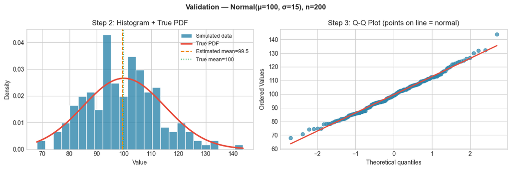

```python
# Simulate a dataset with known parameters
TRUE_MEAN = 100
TRUE_STD  = 15
N_SAMPLES = 200

RNG = np.random.default_rng(42)
data = RNG.normal(loc=TRUE_MEAN, scale=TRUE_STD, size=N_SAMPLES)

# --- Step 1: Summary statistics ---
print('=== Step 1: Summary Statistics ===')
print(f'  n          : {len(data)}')
print(f'  True mean  : {TRUE_MEAN}   | Estimated: {data.mean():.3f}')
print(f'  True std   : {TRUE_STD}    | Estimated: {data.std(ddof=1):.3f}')
print(f'  Median     : {np.median(data):.3f}')
print(f'  IQR        : {np.percentile(data, 75) - np.percentile(data, 25):.3f}')
print(f'  Skewness   : {stats.skew(data):.3f}  (0 = symmetric)')
print(f'  Kurtosis   : {stats.kurtosis(data):.3f}  (0 = normal tails)')

# --- Steps 2 & 3: Visual validation ---
fig, (ax1, ax2) = plt.subplots(1, 2, figsize=(12, 4))
fig.suptitle(f'Validation — Normal(μ={TRUE_MEAN}, σ={TRUE_STD}), n={N_SAMPLES}',
             fontsize=12, fontweight='bold')

# Histogram
ax1.hist(data, bins=25, density=True, color=COLORS['primary'], edgecolor='white', alpha=0.8, label='Simulated data')
x_range = np.linspace(data.min(), data.max(), 200)
ax1.plot(x_range, stats.norm.pdf(x_range, TRUE_MEAN, TRUE_STD),
         color=COLORS['danger'], linewidth=2.5, label='True PDF')
ax1.axvline(data.mean(), color=COLORS['accent'], linestyle='--', linewidth=1.5, label=f'Estimated mean={data.mean():.1f}')
ax1.axvline(TRUE_MEAN,   color=COLORS['success'], linestyle=':',  linewidth=1.5, label=f'True mean={TRUE_MEAN}')
ax1.set_xlabel('Value'); ax1.set_ylabel('Density')
ax1.set_title('Step 2: Histogram + True PDF')
ax1.legend(fontsize=9)

# Q-Q plot
stats.probplot(data, dist='norm', plot=ax2)
ax2.set_title('Step 3: Q-Q Plot (points on line = normal)')
ax2.get_lines()[0].set(color=COLORS['primary'], alpha=0.7)
ax2.get_lines()[1].set(color=COLORS['danger'], linewidth=2)

plt.tight_layout()
plt.show()
```

## Part 5: Building the Simulation Toolkit

```python
# =========================================================
#  simulation_toolkit.py  —  core helpers for this series
# =========================================================

_RNG = np.random.default_rng(42)

def set_seed(seed: int = 42) -> None:
    """Reset the global RNG with a new seed."""
    global _RNG
    _RNG = np.random.default_rng(seed)
    print(f'Random seed set to: {seed}')


def simulate_normal(n: int, mean: float = 0, std: float = 1, seed: int = None) -> np.ndarray:
    """Generate n samples from Normal(mean, std)."""
    rng = np.random.default_rng(seed) if seed is not None else _RNG
    return rng.normal(loc=mean, scale=std, size=n)


def simulate_two_groups(
    n1: int, n2: int, mean1: float, mean2: float,
    std: float = 1, seed: int = None
) -> pd.DataFrame:
    """Generate two independent normal samples and return as a tidy DataFrame."""
    rng = np.random.default_rng(seed) if seed is not None else _RNG
    g1 = rng.normal(loc=mean1, scale=std, size=n1)
    g2 = rng.normal(loc=mean2, scale=std, size=n2)
    return pd.DataFrame({
        'group':     ['Group A'] * n1 + ['Group B'] * n2,
        'value':     np.concatenate([g1, g2]),
        'true_mean': [mean1] * n1    + [mean2] * n2,
    })


def simulate_regression(
    n: int, beta0: float = 0, beta1: float = 1,
    noise_std: float = 1, seed: int = None
) -> pd.DataFrame:
    """Generate data from y = beta0 + beta1*x + epsilon."""
    rng = np.random.default_rng(seed) if seed is not None else _RNG
    x = rng.uniform(0, 10, n)
    y_true = beta0 + beta1 * x
    y = y_true + rng.normal(0, noise_std, n)
    return pd.DataFrame({'x': x, 'y': y, 'y_true': y_true})


def simulate_logistic(
    n: int, beta0: float = 0, beta1: float = 1, seed: int = None
) -> pd.DataFrame:
    """Generate binary outcome data from a logistic model."""
    rng = np.random.default_rng(seed) if seed is not None else _RNG
    x = rng.uniform(-3, 3, n)
    p = 1 / (1 + np.exp(-(beta0 + beta1 * x)))
    y = rng.binomial(1, p)
    return pd.DataFrame({'x': x, 'p_true': p, 'y': y})


def verify_estimate(
    estimate: float, true_value: float, label: str = 'Parameter'
) -> float:
    """Print a comparison table and return relative error (%)"""
    rel_err = abs(estimate - true_value) / abs(true_value) * 100
    bias    = estimate - true_value
    print(f'{label}:')
    print(f'  True value  : {true_value:.4f}')
    print(f'  Estimate    : {estimate:.4f}')
    print(f'  Bias        : {bias:+.4f}')
    print(f'  Relative err: {rel_err:.2f}%')
    return rel_err


print('simulation_toolkit loaded. Available functions:')
print('  set_seed(), simulate_normal(), simulate_two_groups(),')
print('  simulate_regression(), simulate_logistic(), verify_estimate()')
```

```
simulation_toolkit loaded. Available functions:
  set_seed(), simulate_normal(), simulate_two_groups(),
  simulate_regression(), simulate_logistic(), verify_estimate()
```

## Part 6: Toolkit in Action

A quick demonstration of each function, plus a preview of how all four posts in this series will use them.

```python
# --- simulate_normal + verify_estimate ---
print('--- simulate_normal ---')
sample = simulate_normal(n=500, mean=50, std=10, seed=42)
verify_estimate(sample.mean(), true_value=50, label='Mean')
verify_estimate(sample.std(ddof=1), true_value=10, label='Std')

print()

# --- simulate_two_groups ---
print('--- simulate_two_groups ---')
df_groups = simulate_two_groups(n1=100, n2=100, mean1=10, mean2=12, std=2, seed=42)
print(df_groups.groupby('group')['value'].describe().round(3).to_string())

print()

# --- simulate_regression ---
print('--- simulate_regression ---')
df_reg = simulate_regression(n=200, beta0=5, beta1=2.5, noise_std=3, seed=42)
print(df_reg.describe().round(3).to_string())

print()

# --- simulate_logistic ---
print('--- simulate_logistic ---')
df_logit = simulate_logistic(n=500, beta0=-1, beta1=1.5, seed=42)
print(f'Outcome prevalence: {df_logit.y.mean():.2%}')
print(df_logit[['x', 'p_true', 'y']].describe().round(3).to_string())
```

```
--- simulate_normal ---
Mean:
  True value  : 50.0000
  Estimate    : 49.8687
  Bias        : -0.1313
  Relative err: 0.26%
Std:
  True value  : 10.0000
  Estimate    : 9.5993
  Bias        : -0.4007
  Relative err: 4.01%

--- simulate_two_groups ---
          count   mean   std   min    25%    50%    75%    max
group
Group A 100.000  9.899 1.553 6.098  8.912  9.996 11.070 14.283
Group B 100.000 11.979 1.959 7.736 10.506 11.741 12.987 17.828

--- simulate_regression ---
            x       y  y_true
count 200.000 200.000 200.000
mean    4.939  17.396  17.347
std     2.823   8.186   7.058
min     0.074  -0.649   5.184
25%     2.522  10.592  11.305
50%     4.790  18.155  16.975
75%     7.472  24.316  23.681
max     9.924  34.818  29.809

--- simulate_logistic ---
Outcome prevalence: 39.60%
            x  p_true       y
count 500.000 500.000 500.000
mean   -0.026   0.390   0.396
std     1.721   0.359   0.490
min    -2.967   0.004   0.000
25%    -1.584   0.033   0.000
50%     0.005   0.271   0.000
75%     1.483   0.773   1.000
max     2.995   0.970   1.000
```

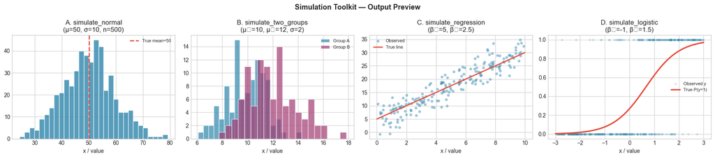

```python
# --- Visual overview of all four function outputs ---
fig, axes = plt.subplots(1, 4, figsize=(18, 4))
fig.suptitle('Simulation Toolkit — Output Preview', fontsize=13, fontweight='bold')

# Panel A: simulate_normal
data_norm = simulate_normal(500, mean=50, std=10, seed=42)
axes[0].hist(data_norm, bins=30, color=COLORS['primary'], edgecolor='white', alpha=0.8)
axes[0].axvline(50, color=COLORS['danger'], linestyle='--', linewidth=2, label='True mean=50')
axes[0].set_title('A. simulate_normal\n(μ=50, σ=10, n=500)')
axes[0].legend(fontsize=8)

# Panel B: simulate_two_groups
df2 = simulate_two_groups(100, 100, mean1=10, mean2=12, std=2, seed=42)
for grp, color in zip(['Group A', 'Group B'], [COLORS['primary'], COLORS['secondary']]):
    axes[1].hist(df2[df2.group == grp]['value'], bins=20, alpha=0.7, color=color, edgecolor='white', label=grp)
axes[1].set_title('B. simulate_two_groups\n(μ₁=10, μ₂=12, σ=2)')
axes[1].legend(fontsize=8)

# Panel C: simulate_regression
df_r = simulate_regression(200, beta0=5, beta1=2.5, noise_std=3, seed=42)
axes[2].scatter(df_r.x, df_r.y, alpha=0.4, s=15, color=COLORS['primary'], label='Observed')
x_line = np.linspace(0, 10, 100)
axes[2].plot(x_line, 5 + 2.5 * x_line, color=COLORS['danger'], linewidth=2, label='True line')
axes[2].set_title('C. simulate_regression\n(β₀=5, β₁=2.5)')
axes[2].legend(fontsize=8)

# Panel D: simulate_logistic
df_l = simulate_logistic(500, beta0=-1, beta1=1.5, seed=42)
axes[3].scatter(df_l.x, df_l.y, alpha=0.15, s=10, color=COLORS['primary'], label='Observed y')
x_s = np.linspace(-3, 3, 200)
p_s = 1 / (1 + np.exp(-(-1 + 1.5 * x_s)))
axes[3].plot(x_s, p_s, color=COLORS['danger'], linewidth=2.5, label='True P(y=1)')
axes[3].set_title('D. simulate_logistic\n(β₀=-1, β₁=1.5)')
axes[3].legend(fontsize=8)

for ax in axes:
    ax.set_xlabel('x / value')

plt.tight_layout()
plt.show()
```

## Part 7: Parameter Sweep — How Sample Size Affects Accuracy

The Law of Large Numbers says that estimates improve as n increases. Let's verify this directly.

```python
TRUE_MEAN = 100
TRUE_STD  = 15

sample_sizes   = [10, 30, 50, 100, 300, 500, 1000, 3000]
n_repetitions  = 500  # repeat each sample size 500 times

results = []
for n in sample_sizes:
    rng = np.random.default_rng(42)
    estimates = [rng.normal(TRUE_MEAN, TRUE_STD, n).mean() for _ in range(n_repetitions)]
    results.append({
        'n':          n,
        'mean_est':   np.mean(estimates),
        'std_est':    np.std(estimates),
        'mae':        np.mean(np.abs(np.array(estimates) - TRUE_MEAN)),
        'theoretical_se': TRUE_STD / np.sqrt(n),
    })

df_sweep = pd.DataFrame(results)
print('Results (averaged over 500 repetitions per n):')
print(df_sweep.to_string(index=False))
```

```
Results (averaged over 500 repetitions per n):
   n  mean_est  std_est   mae  theoretical_se
  10    99.702    4.878 3.930           4.743
  30    99.854    2.779 2.207           2.739
  50   100.125    2.153 1.728           2.121
 100    99.992    1.559 1.228           1.500
 300    99.950    0.868 0.694           0.866
 500   100.002    0.690 0.546           0.671
1000    99.992    0.465 0.360           0.474
3000   100.009    0.270 0.213           0.274
```

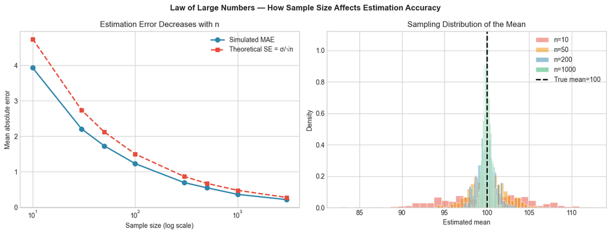

```
Key insight: the spread of estimated means narrows as n grows,
and the simulated SD closely tracks the theoretical SE = σ/√n.
```

```python
fig, (ax1, ax2) = plt.subplots(1, 2, figsize=(13, 5))
fig.suptitle('Law of Large Numbers — How Sample Size Affects Estimation Accuracy',
             fontsize=12, fontweight='bold')

# Left: MAE vs n
ax1.plot(df_sweep['n'], df_sweep['mae'], 'o-', color=COLORS['primary'],
         linewidth=2, markersize=7, label='Simulated MAE')
ax1.plot(df_sweep['n'], df_sweep['theoretical_se'], 's--', color=COLORS['danger'],
         linewidth=2, markersize=6, label='Theoretical SE = σ/√n')
ax1.set_xscale('log')
ax1.set_xlabel('Sample size (log scale)')
ax1.set_ylabel('Mean absolute error')
ax1.set_title('Estimation Error Decreases with n')
ax1.legend()

# Right: distribution of estimates at selected n
colors_sel = [COLORS['danger'], COLORS['accent'], COLORS['primary'], COLORS['success']]
for col, n in zip(colors_sel, [10, 50, 200, 1000]):
    rng = np.random.default_rng(42)
    ests = [rng.normal(TRUE_MEAN, TRUE_STD, n).mean() for _ in range(n_repetitions)]
    ax2.hist(ests, bins=35, density=True, alpha=0.5, color=col, edgecolor='white', label=f'n={n}')
ax2.axvline(TRUE_MEAN, color='black', linestyle='--', linewidth=2, label=f'True mean={TRUE_MEAN}')
ax2.set_xlabel('Estimated mean')
ax2.set_ylabel('Density')
ax2.set_title('Sampling Distribution of the Mean')
ax2.legend()

plt.tight_layout()
plt.show()

print('\nKey insight: the spread of estimated means narrows as n grows,')
print('and the simulated SD closely tracks the theoretical SE = σ/√n.')
```

## Summary

[output not shown]

**Next post →** Descriptive Statistics in Practice: verifying the Law of Large Numbers with normal data, and when to prefer median over mean.

*Python Statistical Analysis in Practice — Post 01 of the series*  
*Author: Jason JJ Li · PKU Institute of Population Research*